# Ответы на исследовательские вопросы

Игорь Панарин

16.11.2021

Загружаем библиотеки и данные

```r
library(rio)
library(skimr)
library(tidyverse)
library(dplyr)
library(multcomp)
PISA <- import("PISA.sav")
```

**ИССЛЕДОВАТЕЛЬСКИЙ ВОПРОС №1**

*Одинакова ли частота адаптации уроков учителями естественно-научного цикла под запросы класса (ST107Q01NA) в Испании, Турции и России?*

Формализуем условия: у нас имеется 3 независимые выборки, N > 100, 1 независимая переменная (фактор) - частота адаптации; H<sub>0</sub>: µ<sub>esp</sub> = µ<sub>tur</sub> = µ<sub>rus</sub>; H<sub>1</sub>: µ<sub>esp</sub> ≠ µ<sub>tur</sub> ≠ µ<sub>rus</sub>

**Метод ответа на вопрос:** one-way ANOVA к последующим применением критерия Тьюки

Выбираем нужные переменные из PISA: CNT; ST107Q01NA

```r
Research1 <- dplyr::select (PISA,
                CNT,
              ST107Q01NA)
```

Удаляем миссинги, переименовываем переменные

```r
Research1 <- na.omit(Research1)
Research1 <- rename(
  Research1, Country = CNT, frequency = ST107Q01NA)
```

Стандартизуем значения frequency

```r
Research1$st_frequency <- scale(Research1$frequency)
```

Посмотрим среднюю frequency по странам, проверим размеры выборок по странам

```r
means_frequency <- Research1 %>%
  group_by (Country) %>%
  summarise (avg = mean(st_frequency, na.rm = T))
means_frequency
```

```
## # A tibble: 3 x 2
##   Country     avg
##   <chr>     <dbl>
## 1 ESP     -0.0286
## 2 RUS      0.0615
## 3 TUR     -0.0331
```

```r
tab1 <- table(Research1$Country)
tab1
```

```
##
##  ESP  RUS  TUR
## 5420 5339 5245
```

Построим 95%-е доверительные интервалы по странам

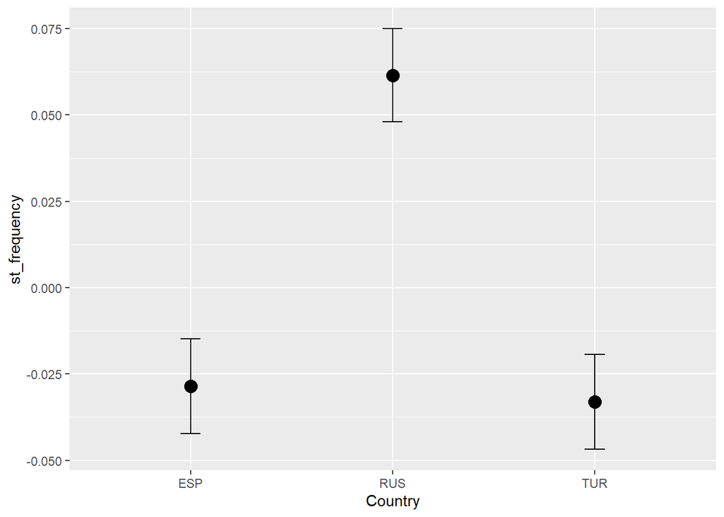

```r
library (ggplot2)
ggplot(Research1, aes(x=Country , y=st_frequency)) +
 stat_summary(fun.Research1 = mean_cl_normal, geom = "errorbar", width = 0.1) + # ДИ
  stat_summary(fun.y = mean, geom = "point", size = 4) # среднее
```

Визуально всё ясно - значимое различие по средним имеется в отношении России, а между Испанией и Турцией - нет. Но убедимся в незначимости различий между Испанией и Турцией через парный t-test:

```r
Research1_1 <- Research1 %>%
  filter(Country == "ESP" | Country =="TUR")
t.test(st_frequency  ~ Country, Research1_1)
```

```
##
##  Welch Two Sample t-test
##
## data:  st_frequency by Country
## t = 0.23307, df = 10660, p-value = 0.8157
## alternative hypothesis: true difference in means between group ESP and group TUR is not equal to 0
## 95 percent confidence interval:
##  -0.03360550  0.04267544
## sample estimates:
## mean in group ESP mean in group TUR
##       -0.02855332       -0.03308828
```

Получили p-value >> alpha = 0.05: различие средний TUR и ESP статистически-незначимо. Теперь убедимся, что существенное различие имеется где-то между тремя странами через ANOVA:

```r
anova1 <- aov(st_frequency ~ Country, Research1)
summary(anova1)
```

```
##                Df Sum Sq Mean Sq F value   Pr(>F)
## Country         2     30  15.175    15.2 2.54e-07 ***
## Residuals   16001  15973   0.998
## ---
## Signif. codes:  0 '***' 0.001 '**' 0.01 '*' 0.05 '.' 0.1 ' ' 1
```

Различия значимы на уровне p<0.001: хотя бы одна группа отличается. Теперь убедимся, что этой группой является Россия. Для этого используем критерий Тьюки:

```r
TukeyHSD(anova1)
```

```
##   Tukey multiple comparisons of means
##     95% family-wise confidence level
##
## Fit: aov(formula = st_frequency ~ Country, data = Research1)
##
## $Country
##                 diff         lwr         upr     p adj
## RUS-ESP  0.090045548  0.04488971  0.13520139 0.0000089
## TUR-ESP -0.004534968 -0.04989419  0.04082426 0.9701802
## TUR-RUS -0.094580516 -0.14010864 -0.04905239 0.0000034
```

Видим по столбцу p adj (p-value), что статистически-значимая разница - между RUS и ESP и между RUS и TUR, что согласуется с визуальной оценкой различий. Ради интереса построим график результатов попарных сравнений

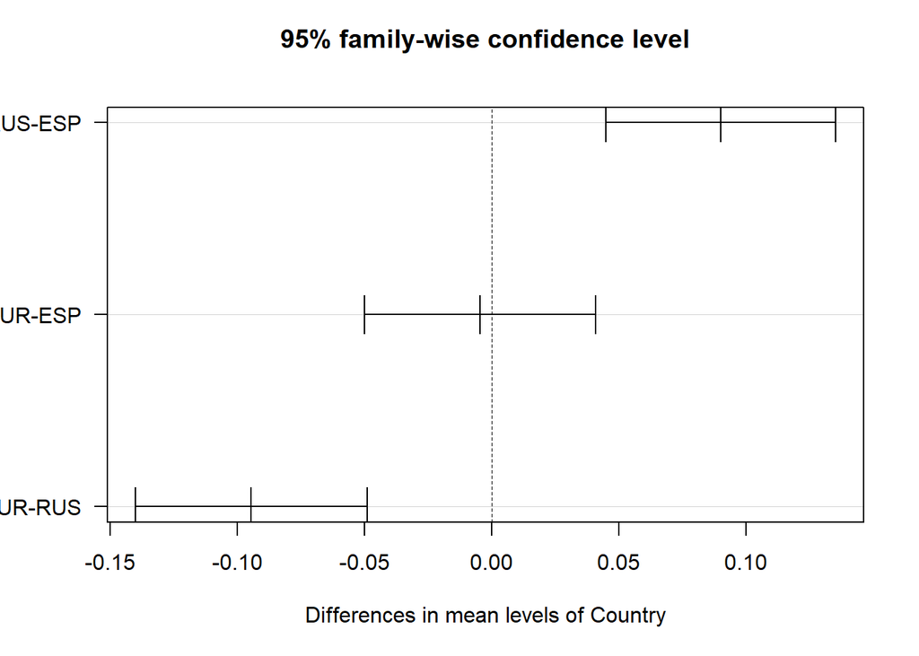

```r
plot(TukeyHSD(anova1), las = 1)
```

Там, где ДИ пересекает пунктир различия статистически-незначимы: TUR-ESP.

**Ответ на ИВ#1:** Частота адаптации уроков учителями одинакова в Испании и в Турции, но в России она значимо выше.

**ИССЛЕДОВАТЕЛЬСКИЙ ВОПРОС №2**

*Различаются ли стандартизированные баллы учащихся по естествознанию в зависимости от того, как часто учителя естественно-научного цикла адаптируют уроки под запросы класса (ST107Q01NA) в России?*

Формализуем условия: у нас имеется 1 независимая переменная (балл учащихся) и 4 группы (в соответствии с номинальной шкалой частоты адаптации)

**Метод ответа на вопрос:** ANOVA с последующим применением критерия Тьюки

Выбираем нужные переменные из PISA: CNT; PV___SCIE; ST107Q01NA, фильтруем по России, создаем переменную science как среднее по PV, организуем всё как надо

```r
Research2 <-dplyr::select (PISA,
                CNT,
                starts_with("PV") & ends_with ("SCIE"),
              ST107Q01NA)
Research2$science <- rowMeans(Research2[,c(2,3,4,5,6,7,8,9,10,11)])
Research2 <- rename(
  Research2, country = CNT, frequency = ST107Q01NA)
Research2 <- Research2 %>%
  filter (country == "RUS")
Research2 <- na.omit(Research2) #удаляем миссинги
Research2$st_science <- scale(Research2$science) #стандартизуем SCIENCE
Research2 <- dplyr::select(Research2, "country", "st_science", "frequency")
```

```r
Research2$frequency2 <- factor(Research2$frequency, levels = c(1,2,3,4))
levels(Research2$frequency2) <- c("NEVER", "SOMETIMES", "USUALLY", "ALWAYS")
table(Research2$frequency2)
```

```
##
##     NEVER SOMETIMES   USUALLY    ALWAYS
##       624      1899      1761      1055
```

Посмотрим визуально ДИ и средние

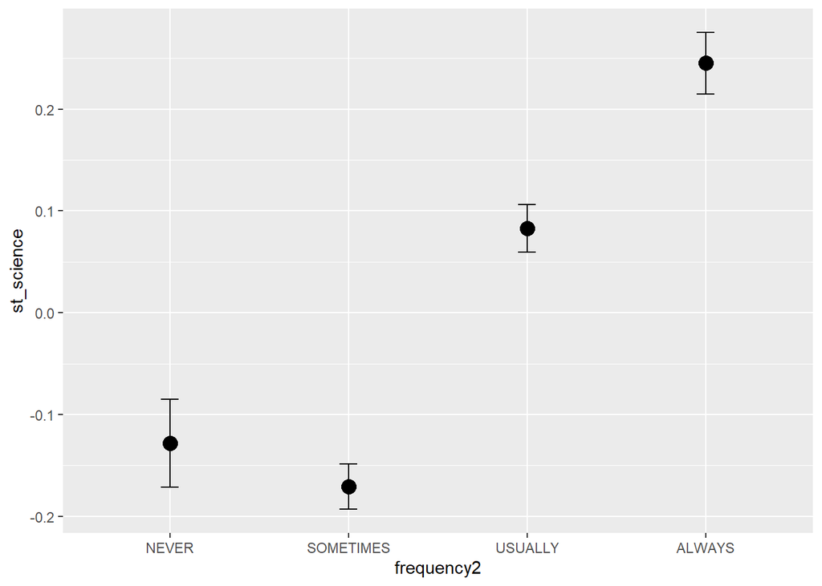

```r
ggplot(Research2, aes(x=frequency2 , y=st_science)) +
 stat_summary(fun.Research1 = mean_cl_normal, geom = "errorbar", width = 0.1) + # ДИ
  stat_summary(fun.y = mean, geom = "point", size = 4) # среднее
```

Видим, что баллы точно различаются значимо во всех случаях кроме одного - NEVER и SOMETIMES. Проверим эту интерпретацию через ANOVA

```r
anova2 <- aov(st_science ~ frequency2, Research2)
summary(anova2)
```

```
##               Df Sum Sq Mean Sq F value Pr(>F)
## frequency2     3    141   47.13   48.38 <2e-16 ***
## Residuals   5335   5197    0.97
## ---
## Signif. codes:  0 '***' 0.001 '**' 0.01 '*' 0.05 '.' 0.1 ' ' 1
```

ANOVA подтверждает наличие значимых различий на p<0.001. Проверим незначимость отличий между NEVER и SOMETIMES через критерий Тьюки

```r
TukeyHSD(anova2)
```

```
##   Tukey multiple comparisons of means
##     95% family-wise confidence level
##
## Fit: aov(formula = st_science ~ frequency2, data = Research2)
##
## $frequency2
##                          diff         lwr        upr     p adj
## SOMETIMES-NEVER   -0.04252309 -0.15955475 0.07450858 0.7867075
## USUALLY-NEVER      0.21153797  0.09337762 0.32969831 0.0000255
## ALWAYS-NEVER       0.37362713  0.24553974 0.50171451 0.0000000
## USUALLY-SOMETIMES  0.25406105  0.17015411 0.33796800 0.0000000
## ALWAYS-SOMETIMES   0.41615021  0.31875983 0.51354059 0.0000000
## ALWAYS-USUALLY     0.16208916  0.06334533 0.26083298 0.0001468
```

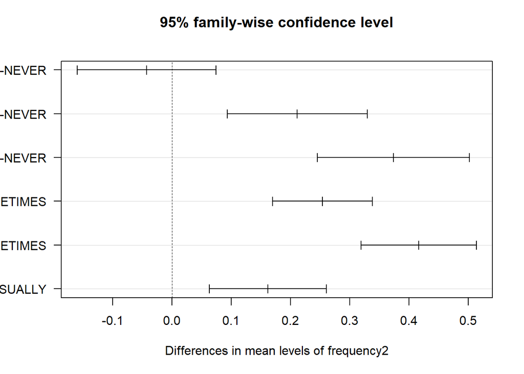

```r
plot(TukeyHSD(anova2), las = 1)
```

P-value для пары SOMETIMES-NEVER >> 0.05: различия статистически-незначимы.

**Ответ на ИВ #2:** стандартизованные баллы учащихся по science значимо различаются в зависимости от частоты адаптации учителем урока под запросы класса во всех случаях, кроме одного: у учителей, которые никогда не адаптируют урок, а также у учителей, которые делают это только иногда, результаты учеников статистически-значимо НЕ отличаются.

**ИССЛЕДОВАТЕЛЬСКИЙ ВОПРОС №3**

*Одинаковы ли стандартизированные баллы учащихся по естествознанию у девочек и мальчиков в России?*

Формализуем условия: у нас имеется 2 независимые выборки (баллы по мальчикам и девочкам), N > 100, 1 независимая переменная - балл; H<sub>0</sub>: µ<sub>мал</sub> = µ<sub>дев</sub>; H<sub>1</sub>: µ<sub>мал</sub> ≠ µ<sub>дев</sub>

**Метод ответа на вопрос:** парный t-test

Организуем нужный дата-фрейм: переменные CNT,SCIENCE (PV__SCIE),GENDER (ST004D01T)

```r
Research3 <- dplyr::select (PISA,
                CNT,
              starts_with("PV") & ends_with ("SCIE"),
              ST004D01T)

Research3$science <- rowMeans(Research3[,c(2,3,4,5,6,7,8,9,10,11)])
Research3 <- rename(
  Research3, country = CNT, gender = ST004D01T)
Research3 <- na.omit(Research3) #удаляем миссинги
Research3 <- Research3 %>%
  filter (country == "RUS")
Research3$st_science <- scale(Research3$science) #стандартизуем SCIENCE
Research3 <- dplyr::select(Research3, "country", "st_science", "gender")
```

Перекодируем переменную gender как факторную с двумя уровнями: MALE, FEMALE

```r
Research3$gender2 <- factor(Research3$gender, levels = c(1,2))
levels(Research3$gender2) <- c("Female", "Male")
table(Research3$gender2)
```

```
##
## Female   Male
##   3107   2929
```

Посмотрим визуально ДИ и средние

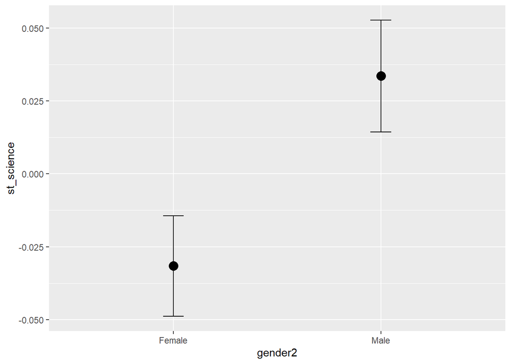

```r
ggplot(Research3, aes(x=gender2 , y=st_science)) +
 stat_summary(fun.Research3 = mean_cl_normal, geom = "errorbar", width = 0.1) + # ДИ
  stat_summary(fun.y = mean, geom = "point", size = 4) # среднее
```

Видим различие, но проверим парным t-test’ом

```r
t.test(st_science  ~ gender2, Research3)
```

```
##
##  Welch Two Sample t-test
##
## data:  st_science by gender2
## t = -2.525, df = 5931, p-value = 0.0116
## alternative hypothesis: true difference in means between group Female and group Male is not equal to 0
## 95 percent confidence interval:
##  -0.11571231 -0.01456568
## sample estimates:
## mean in group Female   mean in group Male
##          -0.03160903           0.03352996
```

p-value = 0.0116 < alpha 0.05 => различия между результатами девочек и мальчиков по science статистически-значимы на уровне значимости p = 0.05